# Titanic gràfiques

Antonio Nogueras i Alex Casanovas

3/6/2021

```r
library(tidyverse)
```

```r
library(ggplot2)
```

## 1. Descripció del dataset:

### dades de Titanic tretes de la Wikipedia, incloent tripulació

### 1.1 Carregar les dades i revisió general

Carregar les dades amb read.csv del fitxer allTitanic.csv = netejat amb CleaningTitanic.ipynb d’all_Titanic.xlsx tret de Wikipedia

```r
allT = read.csv("UOC3/M2.951Tipologia/PRA2/Titanic/allTitanic.csv", header=T)
head(allT,3)
```

```
##   X                             Name Age Boarded  Position Lifeboat  Body Sex
## 1 0                 Mr. George Swane  19       S chauffeur          294MB   m
## 2 1 Miss Amelia Mary "Mildred" Brown  18       S      cook       11         f
## 3 2               Miss Sarah Daniels  33       S      maid        8         f
##   Class      Group Survived ID Adult
## 1     2 1classServ    False  0  True
## 2     2 1classServ     True  1  True
## 3     1 1classServ     True  2  True
```

Vegem la cua:

```r
tail(allT,3)
```

```
##         X                         Name Age Boarded      Position Lifeboat Body
## 2174 2174   Vigott, Mr. Philip Francis  32       S   Able Seaman       13
## 2175 2175 Weller, Mr. William Clifford  30       B   Able Seaman        7
## 2176 2176             Wynn, Mr. Walter  41       B Quartermaster        9
##      Sex Class Group Survived   ID Adult
## 2174   m     0  Deck     True 2174  True
## 2175   m     0  Deck     True 2175  True
## 2176   m     0  Deck     True 2176  True
```

Estructura de les dades llegides:

```r
str(allT)
```

```
## 'data.frame':    2176 obs. of  13 variables:
##  $ X       : int  0 1 2 3 4 5 6 7 8 9 ...
##  $ Name    : Factor w/ 2157 levels "(Kukk, Mr. Jakob?)",..: 1405 1340 1361 1338 1360 1346 1352 1337 1343 1406 ...
##  $ Age     : num  19 18 33 22 46 39 25 36 38 35 ...
##  $ Boarded : Factor w/ 4 levels "B","C","Q","S": 4 4 4 4 2 2 2 2 2 2 ...
##  $ Position: Factor w/ 212 levels "1classPass","2classPass",..: 69 88 147 151 147 151 147 147 147 204 ...
##  $ Lifeboat: Factor w/ 21 levels "","1","10","11",..: 1 4 16 4 12 12 17 16 11 11 ...
##  $ Body    : Factor w/ 254 levels "","-","1{?}MB[90][91]",..: 168 1 1 1 1 1 1 1 1 1 ...
##  $ Sex     : Factor w/ 2 levels "f","m": 2 1 1 1 1 1 1 1 1 2 ...
##  $ Class   : num  2 2 1 1 1 1 1 1 1 1 ...
##  $ Group   : Factor w/ 14 levels "1c0ser","1c1serv",..: 4 4 4 4 4 4 4 4 4 4 ...
##  $ Survived: Factor w/ 2 levels "False","True": 1 2 2 2 2 2 2 2 2 2 ...
##  $ ID      : int  0 1 2 3 4 5 6 7 8 9 ...
##  $ Adult   : Factor w/ 2 levels "False","True": 2 2 2 2 2 2 2 2 2 2 ...
```

Resum i llistat de NA:

```r
# summary() diu si hi ha NA
summary(allT)
```

```
##        X                                             Name           Age
##  Min.   :   0.0   Kelly, Mr. James                     :   3   Min.   : 0.166
##  1st Qu.: 543.8   Andrews, Mr. Thomas                  :   2   1st Qu.:22.000
##  Median :1087.5   Barnes, Mr. Frederick                :   2   Median :29.000
##  Mean   :1087.6   Blake, Mr. Seaton                    :   2   Mean   :29.951
##  3rd Qu.:1631.2   Campbell, Mr. William Henry          :   2   3rd Qu.:36.000
##  Max.   :2176.0   Chisholm, Mr. Roderick Robert Crispin:   2   Max.   :74.000
##                   (Other)                              :2163
##  Boarded            Position      Lifeboat                Body      Sex
##  B: 174   3classPass    :708          :1489                 :1919   f: 469
##  C: 258   1classPass    :284   13     :  65   -             :   2   m:1707
##  Q: 120   2classPass    :278   15     :  59   193MB         :   2
##  S:1624   Fireman/Stoker:158   11     :  46   202MB         :   2
##           Saloon Steward: 90   C      :  45   224MB         :   2
##           Trimmer       : 74   14     :  44   1{?}MB[90][91]:   1
##           (Other)       :584   (Other): 428   (Other)       : 248
##      Class               Group      Survived          ID           Adult
##  Min.   :0.000   3class     :708   False:1489   Min.   :   0.0   False: 134
##  1st Qu.:0.000   Victualling:389   True : 687   1st Qu.: 543.8   True :2042
##  Median :1.000   Engineering:319                Median :1087.5
##  Mean   :1.397   2class     :278                Mean   :1087.6
##  3rd Qu.:3.000   1c0ser     :250                3rd Qu.:1631.2
##  Max.   :3.000   restaurant : 68                Max.   :2176.0
##                  (Other)    :164
```

Queden els de Lifeboat (1489) que són els ofegats, i els de Body (1919) que són els cossos no trobats + els salvats.

### 1.2 Seleccionem columnes per l’anàlisi

```r
selT = allT %>%
  select(Age,Boarded,Lifeboat,Sex,Class,Group,Survived)
head(selT,3)
```

```
##   Age Boarded Lifeboat Sex Class      Group Survived
## 1  19       S            m     2 1classServ    False
## 2  18       S       11   f     2 1classServ     True
## 3  33       S        8   f     1 1classServ     True
```

### 2. La neteja s’ha fet previament en Jupyter amb CleaningTitanic.ipynb inclos en ac-uoc de Github

## 3. Els fets (‘Titanic facts’) en forma gràfica:

### 3.1 Gràfiques de les variables: la numèrica Age

Age, Group i Sex

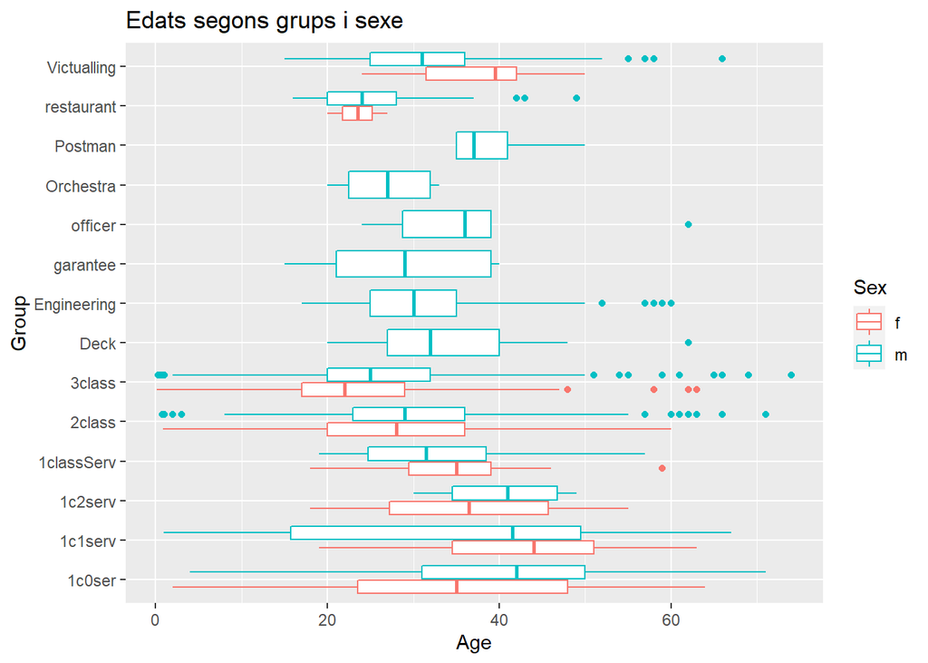

```r
ggplot(selT, aes(x=Age,y=Group,col=Sex)) +
  geom_boxplot() +
  labs(title = 'Edats segons grups i sexe')
```

```r
# edat en funció del grup:

# 1c0ser passatger de primera classe sense servent
# 1c1ser passatger de primera classe amb 1 servent també en 1a
# 1c2ser passatger de primera classe amb 2 servents també en 1a
# 1classServ servent en 1a classe (secretary, valet, nurse,..)
# 2class passatger de segona classe
# 3class passatger de tercera classe
# resta: tripulació (deck, marineria, engineering, tripulació a càrrec de les màquines,..
```

‘Facts’:Entre els tripulants, hi ha outliers que corresponen a personal experimentat, com el capità en officer, o els enginyers d’Enginnering; entre els passatgers, en 2a classe i 3a classe, pels xiquets i hi ha gent molt més major que la mitjana.

Age, Lifeboat i Sex

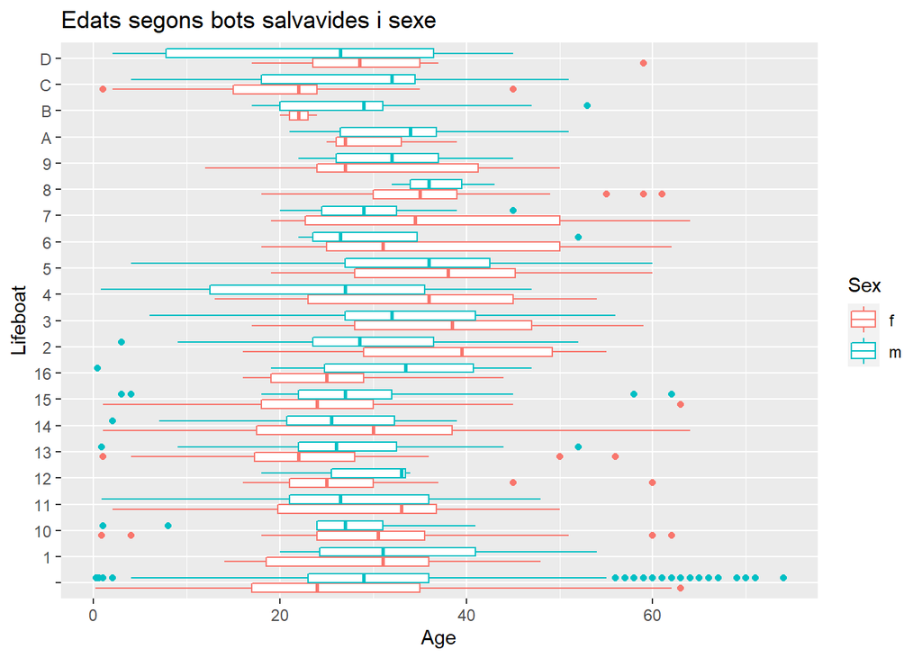

```r
ggplot(selT, aes(x=Age,y=Lifeboat,col=Sex)) +
  geom_boxplot()+
  labs(title = 'Edats segons bots salvavides i sexe')
```

Class, Age i Group

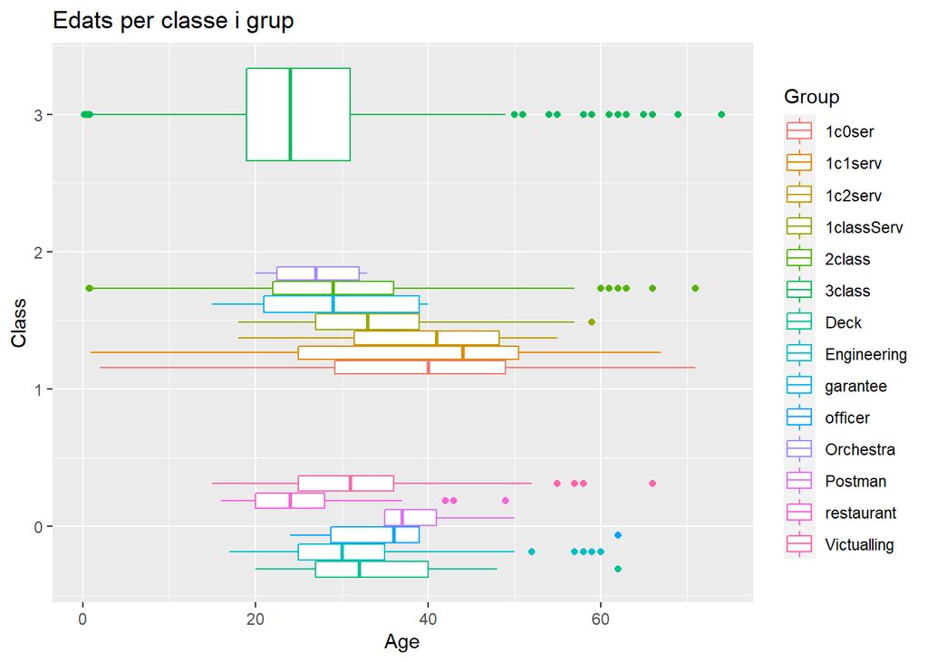

```r
ggplot(allT,aes(y=Class,x=Age,color=Group)) +
  geom_boxplot() +
  labs(title = 'Edats per classe i grup')
```

El gran nombre de outliers en el apartat sense nom són ofegats (‘no boat’)

### 3.2 Gràfiques de les variables tipus factor

Salvats, Lifeboat i Sex

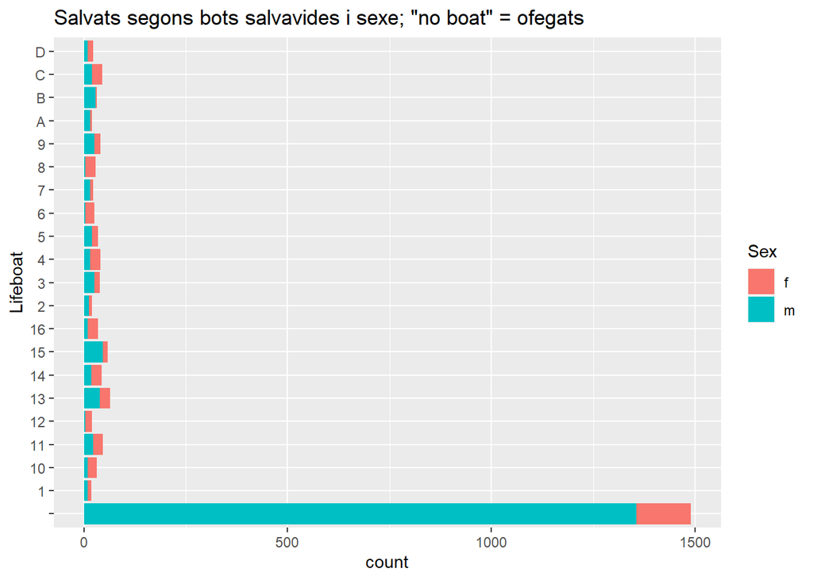

```r
ggplot(data=selT, aes(y=Lifeboat, fill=Sex)) +
  geom_bar() +
  labs(title = 'Salvats segons bots salvavides i sexe; "no boat" = ofegats')
```

Salvats segons grups:

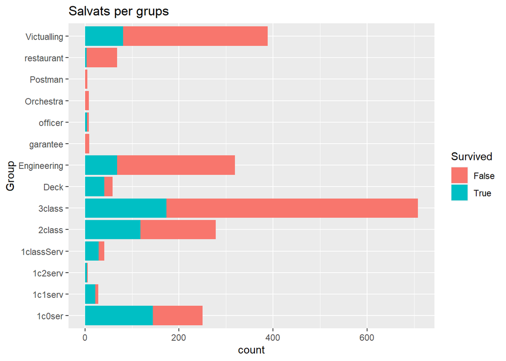

```r
ggplot(selT, aes(fill=Survived, y=Group)) +
  geom_bar()+
  labs(title = 'Salvats per grups')
```

La 3a i 2a classe, entre els passatgers, i tots els tripulants llevat de marineria i oficials són la majoria d’ofegats

Salvats segons sexe:

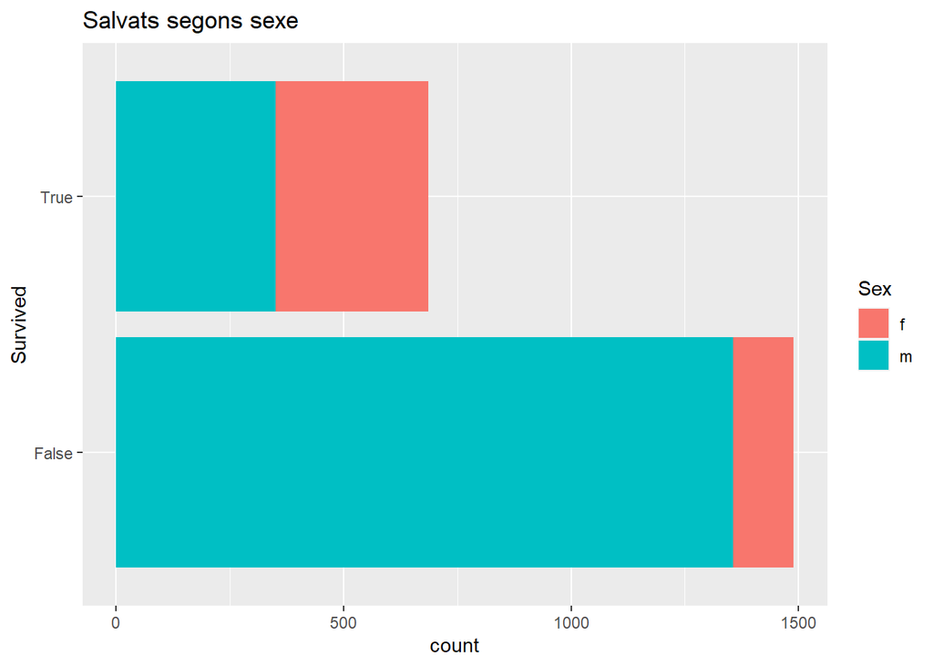

```r
ggplot(selT, aes(y=Survived, fill=Sex)) +
  geom_bar()+
  labs(title = 'Salvats segons sexe')
```

Nens salvats segons sexe:

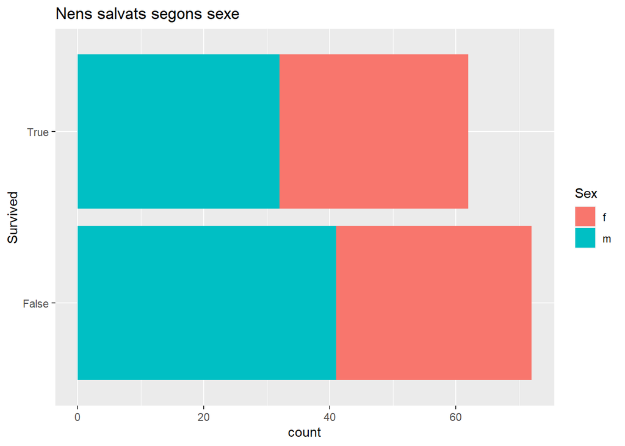

```r
nens=selT %>%
  filter(Age<=15)
ggplot(nens, aes(y=Survived, fill=Sex)) +
  geom_bar()+
  labs(title = 'Nens salvats segons sexe')
```

Un altre tòpic de triatge de nens gens clar: hi ha més nens morts que salvats. No va ser per igual en cada classe, quasi tots els nens ofegats van ser de la 3a classe, com podem veure en el següent gràfic:

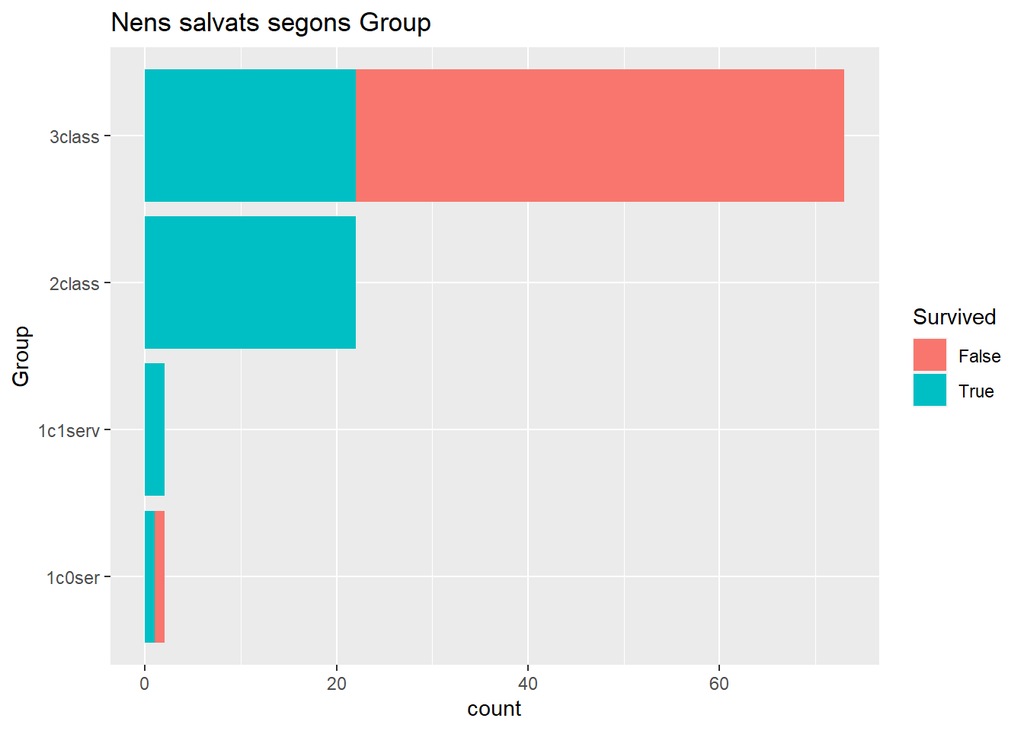

```r
nens=allT %>%
  filter(Age<=10)
ggplot(nens, aes(fill=Survived, y=Group)) +
  geom_bar() +
  labs(title = 'Nens salvats segons Group')
```

Comprovem els salvats segons classe:

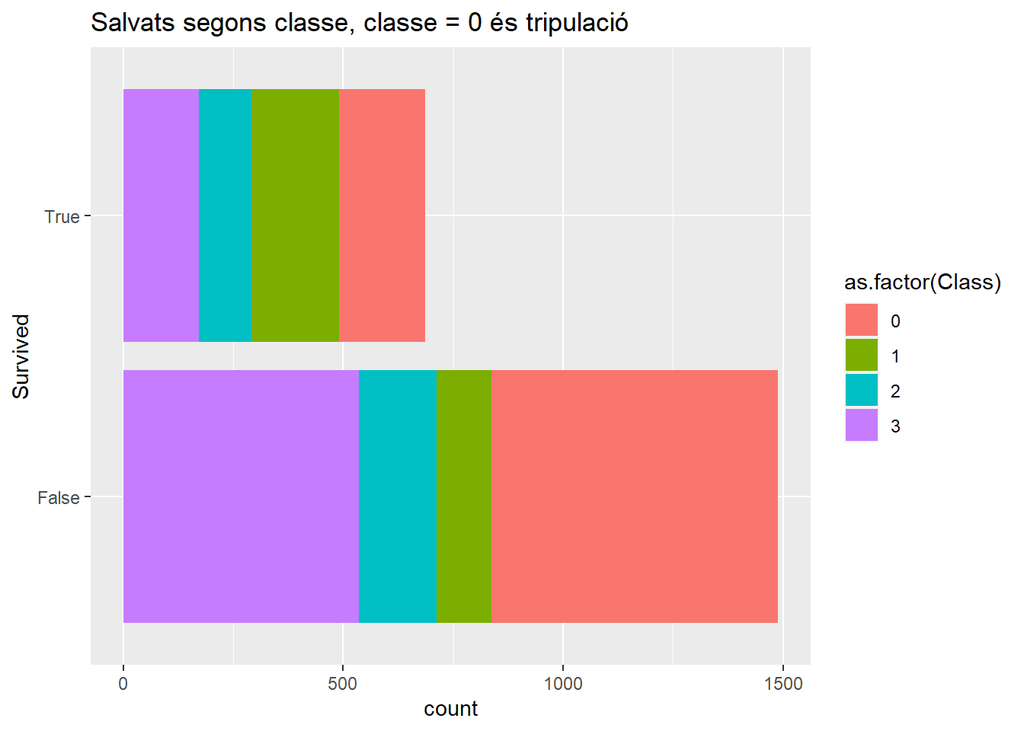

```r
ggplot(selT, aes(y=Survived, fill=as.factor(Class))) +
  geom_bar()+
  labs(title = 'Salvats segons classe, classe = 0 és tripulació')
```

La tripulació i els passatgers de 3a classe van ser els més afectats.

### Regressió lineal sexe vs. salvats

Una teoria estesa diu que les dones del Titanic es van salvar en una proporció molt superior als homes. També és cert que hi havia moltes menys dones que homes al Titanic.

Individualment, cada salvat o ofegat es pot representar per un factor 0 o 1. Si sumem casos, obtenim una variable creixent numèrica.El mateix podem dir de Sex: en el fitxer representa per 0 una dona, per 1 un home, que sumats, ens donen el nombre de homes. El pendent es, per tant, la tasa de salvats dels homes

Per veure com varia l’acumulat de les dos variables, i com el pendent ens dona la probabilitat mitjana de que es salve un home en el Titanic. primer creem estes variables: cSurvived i cSex:

```r
selTn = selT %>%
  select(Sex, Class, Survived) %>%
  mutate_if(is.factor, as.numeric) %>%
  mutate(SexN = Sex - 1, SurvivedN=Survived-1) %>%
  mutate(cSex  = cumsum(SexN), cSurvived = cumsum(SurvivedN))
head(selTn, 3)
```

```
##   Sex Class Survived SexN SurvivedN cSex cSurvived
## 1   2     2        1    1         0    1         0
## 2   1     2        2    0         1    1         1
## 3   1     1        2    0         1    1         2
```

Representarem gràficament cSurvived vs. cSex:

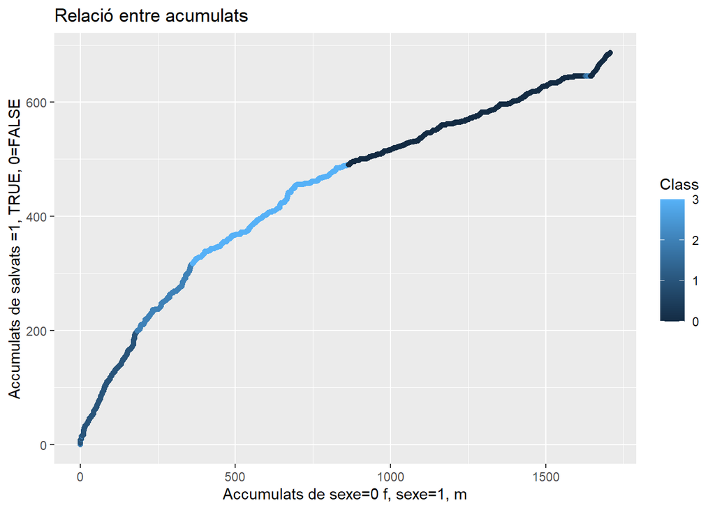

```r
ggplot(selTn, aes(x = cSex, y=cSurvived, color=Class)) +
  geom_point() +
  labs(x='Accumulats de sexe=0 f, sexe=1, m',y='Accumulats de salvats =1, TRUE, 0=FALSE' , title = 'Relació entre acumulats')
```

Ajustem una regressió lineal amb lm() a partir de la meitat, a fi de fer una mostra més representativa:

```r
selTn750 = selTn %>%
  filter(cSex > 750)
surv.fit = lm(cSurvived ~ cSex, data = selTn750)
summary(surv.fit)
```

```
##
## Call:
## lm(formula = cSurvived ~ cSex, data = selTn750)
##
## Residuals:
##      Min       1Q   Median       3Q      Max
## -12.0339  -2.0636  -0.1995   2.1433  16.1775
##
## Coefficients:
##              Estimate Std. Error t value Pr(>|t|)
## (Intercept) 3.008e+02  4.976e-01   604.5   <2e-16 ***
## cSex        2.168e-01  3.973e-04   545.5   <2e-16 ***
## ---
## Signif. codes:  0 '***' 0.001 '**' 0.01 '*' 0.05 '.' 0.1 ' ' 1
##
## Residual standard error: 3.552 on 1008 degrees of freedom
## Multiple R-squared:  0.9966, Adjusted R-squared:  0.9966
## F-statistic: 2.976e+05 on 1 and 1008 DF,  p-value: < 2.2e-16
```

### El pendent 0,217 que s’obté és aproximadament la fracció del total d’homes que se salva. Adjusted R-squared: 0.9966

De la taula de contingència, el valor és 20,6%:

```r
100*prop.table( table(allT$Sex, allT$Survived), margin=1)
```

```
##
##        False     True
##   f 28.35821 71.64179
##   m 79.43761 20.56239
```

## Salvats en xifres

### Salvats per grups

Salvats, en %, segons els grups:

```r
# % de salvats (Survived=True) en funció del grup:

# 1c0ser passatger de primera classe sense servent
# 1c1ser passatger de primera classe amb 1 servent també en 1a
# 1c2ser passatger de primera classe amb 2 servents també en 1a
# 1classServ servent en 1a classe (secretary, valet, nurse,..)
# 2class passatger de segona classe
# 3class passatger de tercera classe
# resta: tripulació (deck, marineria, engineering, tripulació a càrrec de les màquines,..

100*prop.table(table(allT$Group,allT$Survived),margin=1)
```

```
##
##                    False       True
##   1c0ser       42.400000  57.600000
##   1c1serv      21.428571  78.571429
##   1c2serv      33.333333  66.666667
##   1classServ   29.268293  70.731707
##   2class       57.553957  42.446043
##   3class       75.564972  24.435028
##   Deck         30.508475  69.491525
##   Engineering  78.683386  21.316614
##   garantee    100.000000   0.000000
##   officer      50.000000  50.000000
##   Orchestra   100.000000   0.000000
##   Postman     100.000000   0.000000
##   restaurant   95.588235   4.411765
##   Victualling  79.177378  20.822622
```

Els passatgers de 1a classe amb un servent són el grup que més es salva (78,57%), seguit pels mateixos servents acompanyants de 1a classe (70,73).

En valor absolut, els salvats i ofegats (FALSE) són:

```r
table(allT$Group,allT$Survived)
```

```
##
##               False True
##   1c0ser        106  144
##   1c1serv         6   22
##   1c2serv         2    4
##   1classServ     12   29
##   2class        160  118
##   3class        535  173
##   Deck           18   41
##   Engineering   251   68
##   garantee        9    0
##   officer         4    4
##   Orchestra       8    0
##   Postman         5    0
##   restaurant     65    3
##   Victualling   308   81
```

### Salvats: distribució als bots

Comprovem que plens anaven el bots (1 a 14 caben 65, 15 i 16, 40, els plegables A, B, C i D, 47):

```r
bots=allT %>%
  group_by(Lifeboat) %>%
  count(Survived) %>%
  rename(n_by_boat=n)
bots
```

```
## # A tibble: 21 x 3
## # Groups:   Lifeboat [21]
##    Lifeboat Survived n_by_boat
##    <fct>    <fct>        <int>
##  1 ""       False         1489
##  2 "1"      True            18
##  3 "10"     True            31
##  4 "11"     True            46
##  5 "12"     True            20
##  6 "13"     True            65
##  7 "14"     True            44
##  8 "15"     True            59
##  9 "16"     True            35
## 10 "2"      True            20
## # … with 11 more rows
```

Els 1489 són ofegats. Quin percentatge dels bots anava ple?

La resposta és molt variable: l’1 anava al 27,7% mentre que el 15 sobrecarregat al 147,5%:

```r
bots$capacity=c(NA,rep(65,times=6),40,40,rep(65,times=8),rep(47,times=4))
bots$percentFull=100*bots$n_by_boat/bots$capacity
bots
```

```
## # A tibble: 21 x 5
## # Groups:   Lifeboat [21]
##    Lifeboat Survived n_by_boat capacity percentFull
##    <fct>    <fct>        <int>    <dbl>       <dbl>
##  1 ""       False         1489       NA        NA
##  2 "1"      True            18       65        27.7
##  3 "10"     True            31       65        47.7
##  4 "11"     True            46       65        70.8
##  5 "12"     True            20       65        30.8
##  6 "13"     True            65       65       100
##  7 "14"     True            44       65        67.7
##  8 "15"     True            59       40       148.
##  9 "16"     True            35       40        87.5
## 10 "2"      True            20       65        30.8
## # … with 11 more rows
```

### Al menys 3 bots anaven al 30%, savent que el nombre de bots era insuficient.